# green_space_cleaning

Chris J. Martin

05/06/2021

```r
library(tidyverse)
library(janitor)    # for data cleaning
library(readxl)     # for readig excel files
library(visdat)     # for a quick look at data quality
```

## Processing the data

### Gardens data

Dataset downloaded from [ONS](https://www.ons.gov.uk/economy/environmentalaccounts/datasets/accesstogardensandpublicgreenspaceingreatbritain) on 5th June 2021. Both gardens space and public parks datasets are the April 2020 versions.

```r
# a convenience function for renaming columns
# I am sure there is a better way to do this!
replace_in_column_name <- function(df, pattern, replacement){
  df %>%
    rename_with(.fn = ~ str_replace(.x, pattern, replacement))
}

# read in and clean data
gardens <- read_xlsx(
  "data/osprivateoutdoorspacereferencetables_edited_for_import.xlsx",
  sheet = "MSOA gardens",
  skip = 1) %>%

  # make variables names more conistent
  janitor::clean_names() %>%

  # focus on variables of interest
  select(country_code:msoa_name,
         ends_with("count") |
         starts_with("total")) %>%

  # simplify variables names (now data by housing type has been removed)
  replace_in_column_name("total_", "") %>%
  replace_in_column_name("private_outdoor_space", "gar") %>%
  replace_in_column_name("address", "ad") %>%
  replace_in_column_name("adress", "ad") %>%
  replace_in_column_name("adresses", "ads") %>%
  replace_in_column_name("percentage", "perc") %>%
  replace_in_column_name("_m2", "") %>%
  replace_in_column_name("average", "ave")

# display data for quick visual checks
gardens
```

```
## # A tibble: 8,483 x 18
##    country_code country_name region_code region_name lad_code lad_name msoa_code
##    <chr>        <chr>        <chr>       <chr>       <chr>    <chr>    <chr>
##  1 E92000001    England      E12000007   London      E090000~ City of~ E02000001
##  2 E92000001    England      E12000007   London      E090000~ Barking~ E02000002
##  3 E92000001    England      E12000007   London      E090000~ Barking~ E02000003
##  4 E92000001    England      E12000007   London      E090000~ Barking~ E02000004
##  5 E92000001    England      E12000007   London      E090000~ Barking~ E02000005
##  6 E92000001    England      E12000007   London      E090000~ Barking~ E02000007
##  7 E92000001    England      E12000007   London      E090000~ Barking~ E02000008
##  8 E92000001    England      E12000007   London      E090000~ Barking~ E02000009
##  9 E92000001    England      E12000007   London      E090000~ Barking~ E02000010
## 10 E92000001    England      E12000007   London      E090000~ Barking~ E02000011
## # ... with 8,473 more rows, and 11 more variables: msoa_name <chr>,
## #   houses_ad_count <dbl>, houses_ad_with_gar_count <dbl>,
## #   flats_ad_count <dbl>, flats_ad_with_gar_count <dbl>, flats_gar_count <dbl>,
## #   ad_count <dbl>, ad_with_gar_count <dbl>, gar_total_area <dbl>,
## #   perc_of_ades_with_gar <dbl>, ave_size_of_gar <dbl>
```

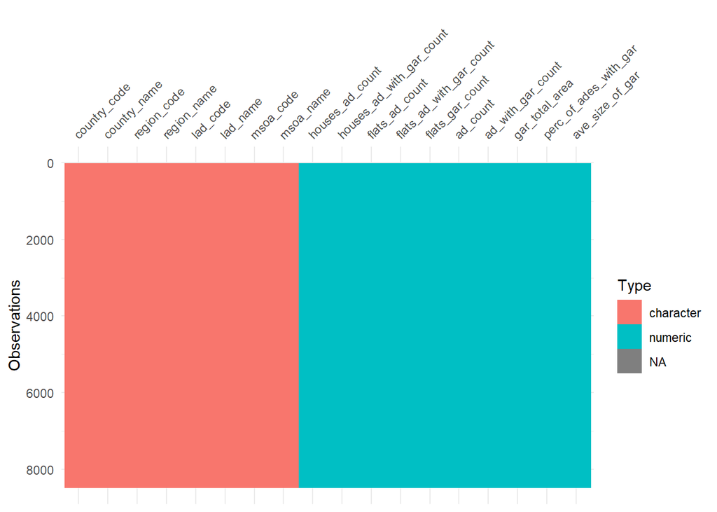

```r
# get a quick visual summary of data types and the amount of missing data
gardens %>%
  visdat::vis_dat()
```

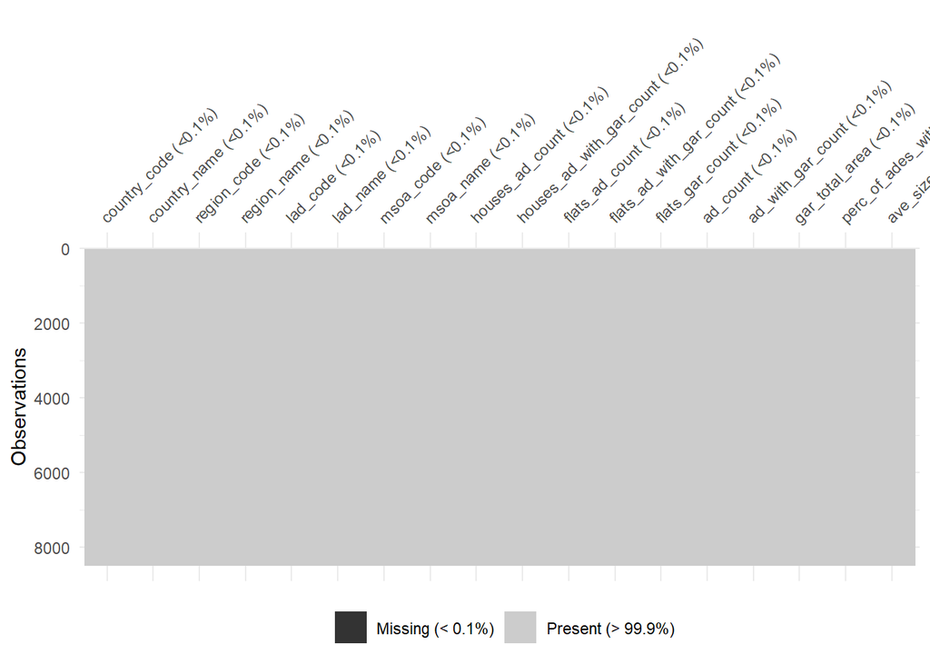

```r
gardens %>%
  visdat::vis_miss()
```

### Population data

ONS provide [MSOA level population data](https://www.ons.gov.uk/peoplepopulationandcommunity/populationandmigration/populationestimates/datasets/middlesuperoutputareamidyearpopulationestimates). Here I use the most recent release (mid 2019).

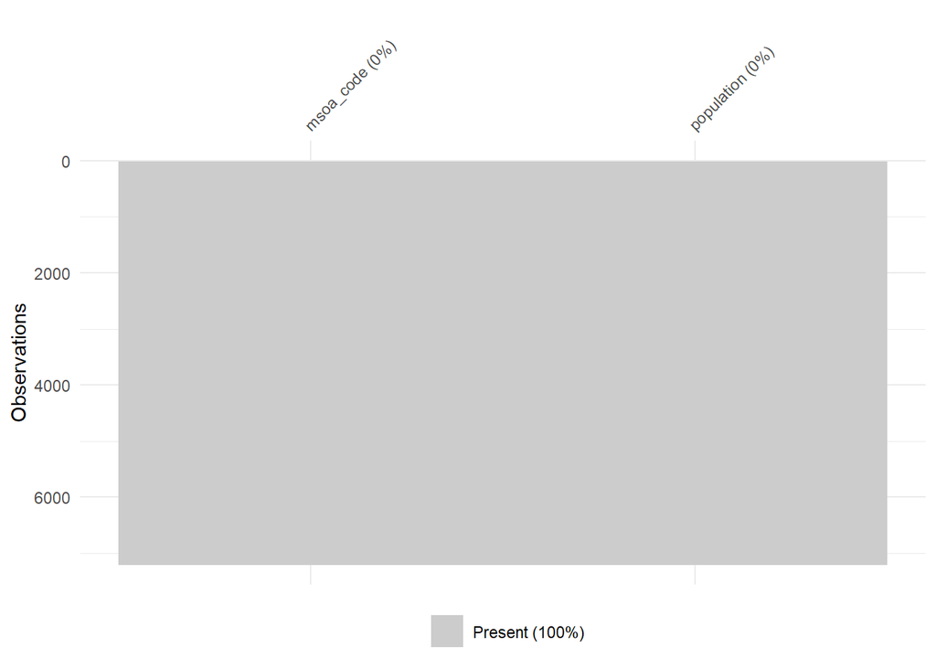

```r
msoa_pops <- read_xlsx(

  "data/SAPE22DT4-mid-2019-msoa-syoa-estimates-unformatted.xlsx",
  sheet = "Mid-2019 Persons",
  skip = 4) %>%

  # process variable names for conistency
  janitor::clean_names() %>%

  # select minimal number of columns
  select(msoa_code, population = all_ages)

msoa_pops %>%
  visdat::vis_miss()
```

### Indicies of multiple deprivation

ONS released the 2019 IMD data at LSOA scale. MySociety have produced [IMD at various other scales](https://research.mysociety.org/sites/imd2019/about/) including the MSOA scale.

```r
imd_2019 <- read_csv("data/imd2019_msoa_level_data.csv")
imd_2019
```

```
## # A tibble: 6,791 x 11
##    MSOAC MSOAHOCLN LAD19C LAD19N REG   LSOACOUNT POPMID15 `IMD19 SCORE` MSOARANK
##    <chr> <chr>     <chr>  <chr>  <chr>     <dbl>    <dbl>         <dbl>    <dbl>
##  1 E020~ City of ~ E0900~ City ~ Lond~         6     6687          14.7     4198
##  2 E020~ Marks Ga~ E0900~ Barki~ Lond~         4     7379          34.8     1060
##  3 E020~ Chadwell~ E0900~ Barki~ Lond~         6    10720          25.1     2200
##  4 E020~ Eastbroo~ E0900~ Barki~ Lond~         4     6536          23.6     2429
##  5 E020~ Becontre~ E0900~ Barki~ Lond~         5     9243          30.2     1519
##  6 E020~ Central ~ E0900~ Barki~ Lond~         5     9664          36.0      965
##  7 E020~ Becontre~ E0900~ Barki~ Lond~         7    12282          34.4     1088
##  8 E020~ Becontre~ E0900~ Barki~ Lond~         6    10504          36.3      945
##  9 E020~ Dagenham~ E0900~ Barki~ Lond~         5     9091          34.5     1083
## 10 E020~ Dagenham~ E0900~ Barki~ Lond~         4     6761          25.7     2122
## # ... with 6,781 more rows, and 2 more variables: MSOADECILE <dbl>,
## #   MSOAQUINTILE <dbl>
```

### Transforming the data for plotting

Overall average = 2.4 (2020 see [here](https://www.ons.gov.uk/peoplepopulationandcommunity/birthsdeathsandmarriages/families/bulletins/familiesandhouseholds/2020))

2017-18 was the most year I could find on [average occupancy figures broken down by house/flat from MCHLG](https://assets.publishing.service.gov.uk/government/uploads/system/uploads/attachment_data/file/817286/EHS_2017-18_Households_Report.pdf):

- House = 2.5 people
- High-rise flat = 1.9
- Mid-rise flat = 1.8

More details [here](https://www.gov.uk/government/statistics/english-housing-survey-2017-to-2018-households).

So for now, I’ll make a conservative assumption that the average occupancy for a flat is 1.8 (i.e. the lower of the mid and high rise figures above).

**I looked at trying to estimate more accurately, but the figures for the number of dwellings per block are not available.**

2020 estimates of the numbers of high and mid rise flat can be found here. These can be used to calculate an average flat occupancy rate.

- 12,500 blocks of high rise flats
- 77,500 blocks of mid rise flats

```r
# calculate occupancy rates
ave_house_occ <- 2.5
ave_flat_occ <- 1.8

gardens %>%
  left_join(msoa_pops) %>%
  mutate(house_ad_without_gar_count = houses_ad_count - houses_ad_with_gar_count,
         flats_ad_without_gar_count = flats_ad_count - flats_ad_with_gar_count,
         pop_without_gar = (ave_house_occ * house_ad_without_gar_count) +
           (ave_flat_occ * flats_ad_without_gar_count))
```

```
## # A tibble: 8,483 x 22
##    country_code country_name region_code region_name lad_code lad_name msoa_code
##    <chr>        <chr>        <chr>       <chr>       <chr>    <chr>    <chr>
##  1 E92000001    England      E12000007   London      E090000~ City of~ E02000001
##  2 E92000001    England      E12000007   London      E090000~ Barking~ E02000002
##  3 E92000001    England      E12000007   London      E090000~ Barking~ E02000003
##  4 E92000001    England      E12000007   London      E090000~ Barking~ E02000004
##  5 E92000001    England      E12000007   London      E090000~ Barking~ E02000005
##  6 E92000001    England      E12000007   London      E090000~ Barking~ E02000007
##  7 E92000001    England      E12000007   London      E090000~ Barking~ E02000008
##  8 E92000001    England      E12000007   London      E090000~ Barking~ E02000009
##  9 E92000001    England      E12000007   London      E090000~ Barking~ E02000010
## 10 E92000001    England      E12000007   London      E090000~ Barking~ E02000011
## # ... with 8,473 more rows, and 15 more variables: msoa_name <chr>,
## #   houses_ad_count <dbl>, houses_ad_with_gar_count <dbl>,
## #   flats_ad_count <dbl>, flats_ad_with_gar_count <dbl>, flats_gar_count <dbl>,
## #   ad_count <dbl>, ad_with_gar_count <dbl>, gar_total_area <dbl>,
## #   perc_of_ades_with_gar <dbl>, ave_size_of_gar <dbl>, population <dbl>,
## #   house_ad_without_gar_count <dbl>, flats_ad_without_gar_count <dbl>,
## #   pop_without_gar <dbl>
```